# Horizon Scan Survey - Your Answers

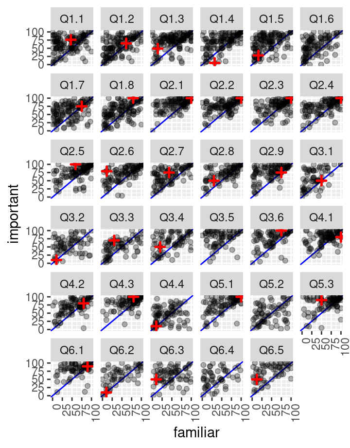

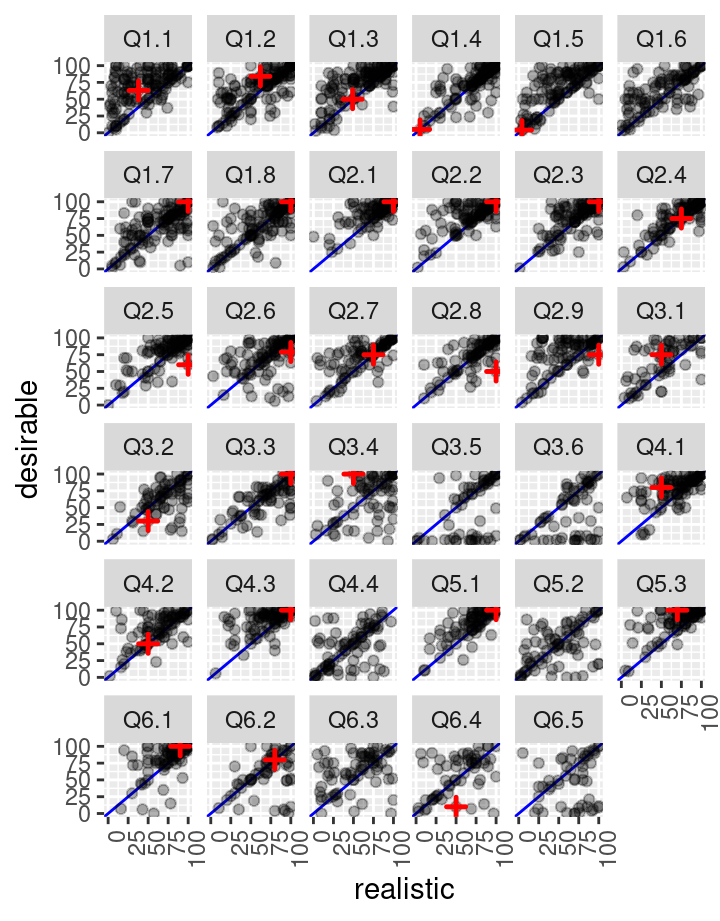

Dear Mathias,

thank you for having participated in our survey! The red symbol in the figures on the right indicates your response.

For each *topic* we had asked you about your familiarity and the importance for the urban storm- and wastewater management sector. Topics with high importance and low familiarity were judged as “novel”.

Additionally we proposed for each topic a *Vision 2030* (scenario). The second plot on the right shows how realistic and how desirable this vision was judged. In particular, undesirable but realistic scenarios can be identified.

The complete description of topics and visions (scenarios) can be found in the [Supporting Information](https://pubs.acs.org/doi/suppl/10.1021/acs.est.8b06481/suppl_file/es8b06481_si_001.pdf) of the publication.

**Publication**

Blumensaat, F., Leitão, J.P., Ort, C., Rieckermann, J., Scheidegger, A., Vanrolleghem, P.A., Villez, K., 2019. How Urban Storm- and Wastewater Management Prepares for Emerging Opportunities and Threats: Digital Transformation, Ubiquitous Sensing, New Data Sources, and Beyond - A Horizon Scan. Environ. Sci. Technol. https://doi.org/10.1021/acs.est.8b06481

### Topics

**New Data Source**

- Q1.1 Onsite High-Resolution Mass Spectrometry
- Q1.2 Autonomous Sensor Platforms and Remote Sensing
- Q1.3 Sensing at High Spatial Resolution
- Q1.4 Low-Tech Sensors
- Q1.5 Micropollutant and Pathogen Monitoring
- Q1.6 Environmental DNA
- Q1.7 Implicit Crowd-Sourcing
- Q1.8 Explicit Crowd-Sourcing

**Data Management and Modelling**

- Q2.1 Data Validation
- Q2.2 Metadata Collection and Organization
- Q2.3 Optimal Experimental Design
- Q2.4 Heterogeneous Data Quality
- Q2.5 Real-Time Models
- Q2.6 Data-Driven Models
- Q2.7 Goal-Oriented Learning
- Q2.8 Software Sensing
- Q2.9 Linking Aquatic Ecology to Emissions

**Interaction Data and Stakeholders**

- Q3.1 Ontologies
- Q3.2 Augmented Reality
- Q3.3 Serious Games
- Q3.4 Smart Meters and Privacy
- Q3.5 Cybersecurity
- Q3.6 Complexity – Blind Trust

**New Water Technologies**

- Q4.1 Decentralization
- Q4.2 Technology Diversification
- Q4.3 Integrated Management
- Q4.4 Data Collected at Personal Resolution

**New Services**

- Q5.1 Secondary Health Benefits
- Q5.2 Public Health Information
- Q5.3 Resource Recovery

**Societal Values and Implementation**

- Q6.1 Regulations
- Q6.2 Index-Based Insurances
- Q6.3 Water Tariffs
- Q6.4 Transparent Compliance Assessment
- Q6.5 Global Changes

### Familiarity vs Importance (Topic)

The red symbol indicates your response.

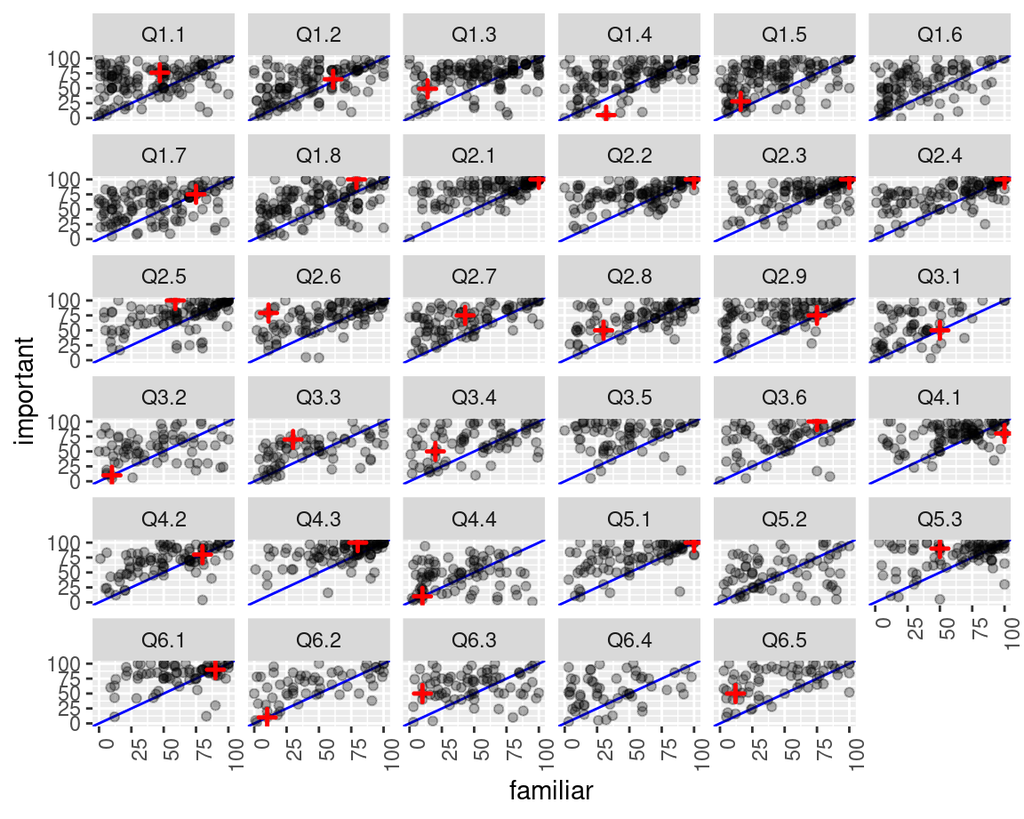

### Desirability vs Realism (Vision 2030)

The red symbol indicates your response.

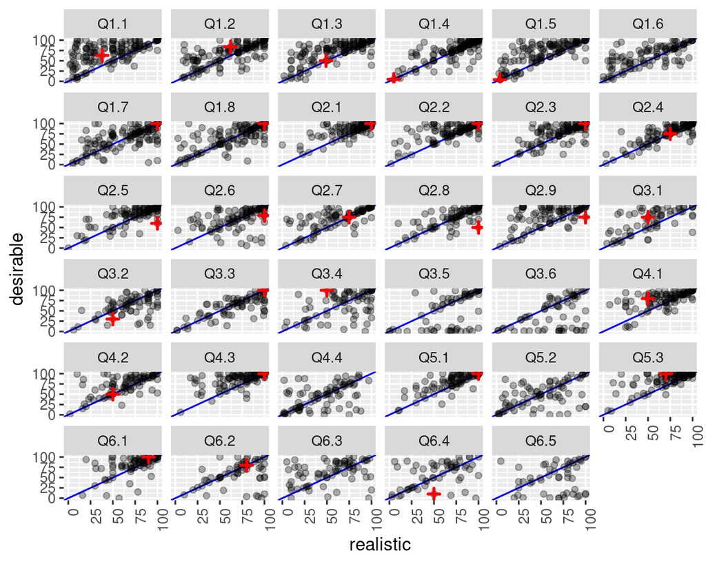